# Data Wrangling Pt. II

# What we’ll cover

- Fancier joins
- Working with text and dates
- Basic plots with ggplot

## Data

```r
ccc<-read_csv('https://dataverse.harvard.edu/api/access/datafile/12027896')
```

# Fancy joins

### Anti-join

```r
library(countrycode)
```

### Cross joins

Also known as a cartesian join. A `cross_join`: creates a row for each row in the LHS and RHS table:

```r
lhs<-tibble(letter = c("A", "B", "C"))
rhs<-tibble(number = c(1, 2) )
combined<-cross_join(lhs, rhs)

combined
```

| letter | number |
| --- | --- |
| A | 1 |
| A | 2 |
| B | 1 |
| B | 2 |
| C | 1 |
| C | 2 |

## Nesting and unnesting

[figure not shown]

### Problem: nested data event data

Since events often include multiple behaviors and claims, CCC variables allow “nested” data, where each value is separated by a semi-colon:

```r
ccc|>
  count(issue_tags_summary)|>
  arrange(-n)|>
  slice_head(n=5)
```

| issue_tags_summary | n |
| --- | --- |
| foreign affairs; war and peace | 5530 |
| civil rights; corruption; democracy; free speech; war and peace; patriotism; presidency | 2127 |
| democracy; war and peace; presidency | 2075 |
| war and peace | 1513 |
| economy; healthcare; war and peace; presidency | 1275 |

How do we (non-destructively) get rid of the nesting from this to get something into the “tidy” format we want for analysis?

### Splitting and unnesting

Once we split up the data, we’ve got three main options that can retain our tabular structure without losing any data: long, wide, or dummied (also known as “one-hot” encoding)

[figure not shown]

### Wide, long, and dummified

- Wide
- Long
- Dummified

Wide format really only works here if the nested list has an ordering (otherwise, the decision to place a value in “issue1” vs. “issue2” is arbitrary)

```r
ccc|>
  select(issue_tags_summary)|>
  mutate(issue_tags_summary = str_split(issue_tags_summary, ";"))|>
  unnest_wider(issue_tags_summary, names_sep='_')|>
  slice_head(n=5)
```

| issue_tags_summary_1 | issue_tags_summary_2 | issue_tags_summary_3 | issue_tags_summary_4 | issue_tags_summary_5 | issue_tags_summary_6 | issue_tags_summary_7 | issue_tags_summary_8 | issue_tags_summary_9 | issue_tags_summary_10 | issue_tags_summary_11 | issue_tags_summary_12 | issue_tags_summary_13 | issue_tags_summary_14 | issue_tags_summary_15 |
| --- | --- | --- | --- | --- | --- | --- | --- | --- | --- | --- | --- | --- | --- | --- |
| banking and finance | economy | foreign affairs | healthcare | war and peace | NA | NA | NA | NA | NA | NA | NA | NA | NA | NA |
| war and peace | policing | NA | NA | NA | NA | NA | NA | NA | NA | NA | NA | NA | NA | NA |
| foreign affairs | war and peace | NA | NA | NA | NA | NA | NA | NA | NA | NA | NA | NA | NA | NA |
| foreign affairs | war and peace | NA | NA | NA | NA | NA | NA | NA | NA | NA | NA | NA | NA | NA |
| economy | foreign affairs | war and peace | NA | NA | NA | NA | NA | NA | NA | NA | NA | NA | NA | NA |

Long format works well with many of our R functions, but *we want to be careful about how we calculate/interpret proportions and counts because multi-issue events would receive more weight than single issue events.*

```r
ccc|>
  select(issue_tags_summary)|>
  mutate(
    event_id = row_number(),
    issue_tags_summary = str_split(issue_tags_summary, ";"))|>
  unnest_longer(issue_tags_summary)|>
  mutate(issue_tags_summary = str_squish(issue_tags_summary))|>
  slice_head(n=5)
```

| issue_tags_summary | event_id |
| --- | --- |
| banking and finance | 1 |
| economy | 1 |
| foreign affairs | 1 |
| healthcare | 1 |
| war and peace | 1 |

Making dummies takes a little more legwork, but it preserves the 1 row per event structure of the original data.

```r
ccc|>
  select(issue_tags_summary)|>
  mutate(
    event_id = row_number(),
    issue_tags_summary = str_split(issue_tags_summary, ";"),
    value = 1
    )|>
  unnest_longer(issue_tags_summary)|>
  mutate(issue_tags_summary = str_squish(issue_tags_summary))|>
  pivot_wider(names_from = issue_tags_summary, values_from =value, values_fill = 0
              )|>
  slice_head(n=5)
```

| event_id | banking and finance | economy | foreign affairs | healthcare | war and peace | policing | corruption | racism | criminal justice | religion | immigration | patriotism | women’s rights | labor and workers rights | energy | environment | guns | legislative | transportation | lgbtqia | animal rights | indigenous peoples | democracy | presidency | housing | reproductive rights | civil rights | education | judiciary | … |
| --- | --- | --- | --- | --- | --- | --- | --- | --- | --- | --- | --- | --- | --- | --- | --- | --- | --- | --- | --- | --- | --- | --- | --- | --- | --- | --- | --- | --- | --- | --- |
| 1 | 1 | 1 | 1 | 1 | 1 | 0 | 0 | 0 | 0 | 0 | 0 | 0 | 0 | 0 | 0 | 0 | 0 | 0 | 0 | 0 | 0 | 0 | 0 | 0 | 0 | 0 | 0 | 0 | 0 | … |
| 2 | 0 | 0 | 0 | 0 | 1 | 1 | 0 | 0 | 0 | 0 | 0 | 0 | 0 | 0 | 0 | 0 | 0 | 0 | 0 | 0 | 0 | 0 | 0 | 0 | 0 | 0 | 0 | 0 | 0 | … |
| 3 | 0 | 0 | 1 | 0 | 1 | 0 | 0 | 0 | 0 | 0 | 0 | 0 | 0 | 0 | 0 | 0 | 0 | 0 | 0 | 0 | 0 | 0 | 0 | 0 | 0 | 0 | 0 | 0 | 0 | … |
| 4 | 0 | 0 | 1 | 0 | 1 | 0 | 0 | 0 | 0 | 0 | 0 | 0 | 0 | 0 | 0 | 0 | 0 | 0 | 0 | 0 | 0 | 0 | 0 | 0 | 0 | 0 | 0 | 0 | 0 | … |
| 5 | 0 | 1 | 1 | 0 | 1 | 0 | 0 | 0 | 0 | 0 | 0 | 0 | 0 | 0 | 0 | 0 | 0 | 0 | 0 | 0 | 0 | 0 | 0 | 0 | 0 | 0 | 0 | 0 | 0 | … |

### Wide, long, and dummified: notes

- All of this can be memory intensive for long strings or big data sets. For those scenarios, we can use methods and packages specifically designed for doing text analysis.
- Nesting is often preferable for storage, transfer, and data entry because it’s compact with minimal repetition. So we typically don’t need to worry about this until we’re at the analysis stage.
- [There’s a set of (currently experimental) tidyr functions](https://tidyr.tidyverse.org/reference/index.html#character-vectors) that combine the split-unnest process into a single command.

## Messy strings

[figure not shown]

### Problem: spelling errors

Some variations on “demonstration” in the CCC data for 2025:

```r
demos<-ccc|>
  filter(str_detect(event_type, ";|,") ==FALSE)|>
  filter(str_detect(tolower(event_type), "demo"))

demos|>
  count(event_type)|>
  arrange(-n)|>
  slice_tail(n=20)|>
  kableExtra::kbl()|>
  kableExtra::kable_classic()
```

| event_type | n |
| --- | --- |
| demonstration | 18935 |
| demonsatration | 17 |
| Demonstration | 11 |
| demonstrations | 3 |
| demosntration | 3 |
| demonstration and sit-in | 2 |
| Demonstartion | 1 |
| demomstration | 1 |
| demonstarion | 1 |
| demonstation | 1 |
| demonstraiton | 1 |
| demonstratiion | 1 |
| demonstratino | 1 |
| demontration | 1 |
| demostration | 1 |
| pdemonstration | 1 |

### “Manual” spelling correction

A labor-intensive - but precise - fix would be to use an exhaustive list of mis-spellings and then a logical expression:

```r
spellings<-c("demonstrations",
             "demonsatration",
             'demosntration',
             'demomstration',
             'Demonstration',
             'demonstration and sit-in',
             'demonstarion',
             'Demonstartion',
             'demonstation',
             'demonstratino',
             'pdemonstration',
             'demonstraiton',
             'demonstratiion',
             'demontration',
             'demostration',
             'demonstration'
             )

demos|>
  mutate(is_demonstration = event_type %in% spellings)|>
  count(is_demonstration)
```

| is_demonstration | n |
| --- | --- |
| TRUE | 18981 |

### Regular Expressions

Instead of typing every possibility, we could use a regular expression to catch values.

- A regular expression is a way to match text patterns. It’s sort of like a wild-card search, but far more flexible.
- Most mature programming languages will have support for using regular expressions (they’re really indespensible for this kind of problem!)

Some examples of regex operators:

[output not shown]

### Regular Expressions

Here’s a regular expression you might use to match “demonstrations”

$$\text{\b[d|D]emo\S+ons*\b}$$

- `\b` denotes a word boundary (start of a string, a space, punctuation mark, or newline)
- `[D|d]` matches either upper case D or lower case D.
- `\S+` will match any non-whitespace character between one and infinite times.
- `ons*\b` means that the word must end with the letters `on` followed by either an `s` or nothing.

(Note that in R you need to escape backslashes, so `\b` will be `\\b`)

I recommend using a graphical interface [this one](https://regex101.com/) to develop and test complex expressions. Then just paste your results into an R command.

### Regular Expressions

`stringr` functions:

- `str_detect` returns `TRUE` if there’s a match *anywhere in the string*
- `str_replace` will replace the first instance of a matching string with something else.
- `str_extract` will extract first instance of the string that matches your regular expression.
- `str_extract_all` and `str_replace_all` will do this for all matches in a string, instead of just the first.

```r
demos|>
  distinct(event_type)|>
  mutate(detect = str_detect(event_type, "\\b[d|D]emo\\S+ons*\\b"),
         replace = str_replace(event_type, "\\b[d|D]emo\\S+ons*\\b", "demonstration"),
         extract = str_extract(event_type, "\\b[d|D]emo\\S+ons*\\b")
         )
```

| event_type | detect | replace | extract |
| --- | --- | --- | --- |
| demonstration | TRUE | demonstration | demonstration |
| demontration | TRUE | demonstration | demontration |
| demostration | TRUE | demonstration | demostration |
| demosntration | TRUE | demonstration | demosntration |
| demonstarion | TRUE | demonstration | demonstarion |
| pdemonstration | FALSE | pdemonstration | NA |
| demomstration | TRUE | demonstration | demomstration |
| demonstation | TRUE | demonstration | demonstation |
| demonsatration | TRUE | demonstration | demonsatration |
| Demonstration | TRUE | demonstration | Demonstration |
| Demonstartion | TRUE | demonstration | Demonstartion |
| demonstratino | FALSE | demonstratino | NA |
| demonstrations | TRUE | demonstration | demonstrations |
| demonstratiion | TRUE | demonstration | demonstratiion |
| demonstration and sit-in | TRUE | demonstration and sit-in | demonstration |
| demonstraiton | TRUE | demonstration | demonstraiton |

### Regular Expressions: Notes

- If you just need a simple string match, it might be better to use `str_detect(coll(x), "string_to_match")` to do literal matching.
- Any kind of wild card matching comes with some risk of errors, so be careful about using this in high-stakes scenarios.
- Regular expressions can be computationally expensive because they require multiple passes through a string.

### Regular Expressions: Notes

This:

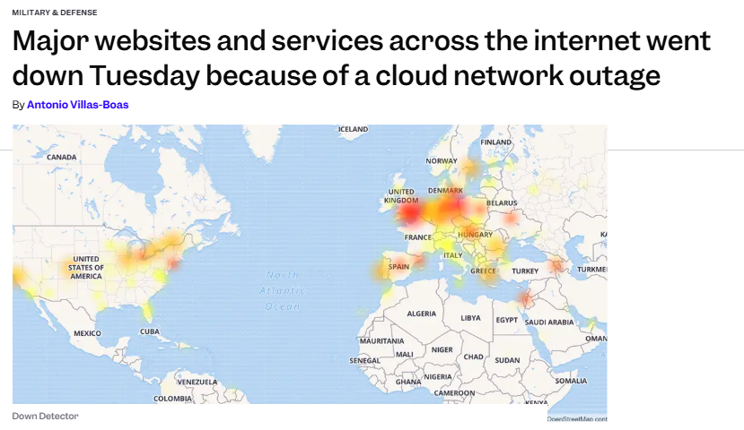

… Was ultimately caused by this regular expression:

```
(?:(?:\"|'|\]|\}|\\|\d|(?:nan|infinity|true|false|null|undefined|symbol|math)|\`|\-|\+)+[)]*;?((?:\s|-|~|!|{}|\|\||\+)*.*(?:.*=.*)))
```

### Making a dictionary with fuzzy matching

Finally, we might try to use some fuzzy matching to facilitate creating a dictionary.

1. Make a list of valid strings and a list of all strings that occur in the data.
2. Quantify the difference between each string.
3. Join any rows where the distance is below some threshold. (typically setting this requires some manual inspection)

### Making a dictionary with fuzzy matching

String Distance:

- There are lots of ways to calculate the “distance” between strings.
- The default for the R package “stringdist” is the restricted Damerau-Levenshtein distance, which counts the number of operations need to transform one string into another.
- A single operation could be:
  - transposing “s” and “n” in “demosntration”
  - removing the “s” “demonstrations” or adding an “n” to “demostration”
  - substituting “m” for “n” in “demomstration”

### Making a dictionary with fuzzy matching

(note: if there’s a really large amount of text, then the `expand.grid` function below might eat up all your memory. So you would probably want to do this using a loop or just use an existing package for text analysis.)

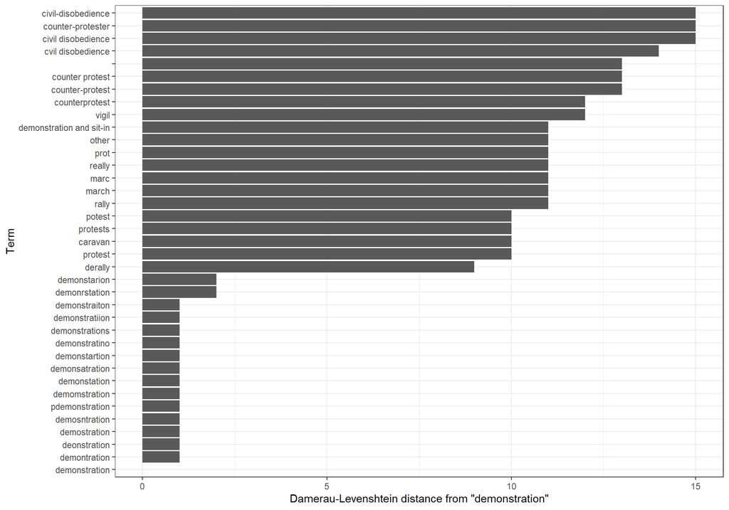

```r
library(stringdist)

valid_event_types = c("demonstration",
                      "rally",
                      "march",
                      "protest",
                      "civil disobedience",
                      "counter-protest")
all_event_types<-ccc|>
  pluck('event_type')|>
  str_split(";")|>
  unlist()|>
  str_to_lower()|>
  str_squish()|>
  na.omit()|>
  unique()



distances<-expand.grid("valid" = valid_event_types,
                       "all"  = all_event_types)|>
  mutate(distance = stringdist(valid, all, method='osa'))|>
  arrange(valid, distance)


distances|>
  filter(valid == "demonstration")|>
  ggplot(aes(x=distance, y=reorder(all, distance))) +
  geom_bar(stat='identity') +
  ylab("Term") +
  xlab("Damerau-Levenshtein distance from \"demonstration\"") +
  theme_bw()
```

### Making a dictionary with fuzzy matching

After some inspection, I decided a distance of around 4 should be the maximum.

```r
dictionary<-distances|>
  group_by(all)|>
  filter(distance < 4)|>
  slice_min(n=1, order_by=distance, with_ties=FALSE)


# viewing the distances for unmatched results:
anti_join(distances, dictionary, by=join_by(all == all))|>
  pivot_wider(names_from = valid, values_from =distance)|>
  kableExtra::kbl(caption='string distances for unmatched strings')|>
  kableExtra::kable_classic()
```

string distances for unmatched strings

| all | demonstration | rally | march | protest | civil disobedience | counter-protest |
| --- | --- | --- | --- | --- | --- | --- |
| caravan | 10 | 5 | 5 | 7 | 16 | 13 |
| other | 11 | 5 | 5 | 5 | 16 | 12 |
| demonstration and sit-in | 11 | 22 | 22 | 20 | 21 | 19 |
| vigil | 12 | 5 | 5 | 7 | 15 | 15 |
|  | 13 | 5 | 5 | 7 | 18 | 15 |

### Making a dictionary with fuzzy matching

Here’s how we might apply this dictionary to get the proportion of events featuring each “type” of activity across all events in the data:

```r
ccc$event_id <- 1:nrow(ccc)

ccc_events<-ccc|>
  mutate(
    event_split = str_split(str_to_lower(event_type), ";"))|>
  select(event_id, event_split)|>
  unnest_longer(event_split)|>
  mutate(event_split = str_squish(event_split))|>
  left_join(dictionary, by =join_by(event_split == all))|>
  select(event_id, valid)|>
  mutate(one = 1)|>
  pivot_wider(names_from = valid, values_from = one, values_fill = 0)


colMeans(ccc_events[,2:ncol(ccc_events)])
```

```
     demonstration              rally              march    counter-protest
       0.757491551        0.134209538        0.093203154        0.016259857
civil disobedience            protest                 NA
       0.003529854        0.099887345        0.004581299
```

(Alternatively, you might just use a left join to add these values back on to the original CCC data)

## Times and dates

Times and dates are complex

- Different date formats: Aug 19, 2025; 2025-19-08; 19 August, 2025…
- Time zones, leap years, and daylight savings
- Calendar/clock math, periods, and intervals

### Times and dates

Base R uses specialized date and time classes to help with these complexities, but you’ll encounter issues if the dates aren’t formatted correctly:

```r
as.Date("01/01/1970")              # everything is wrong here
```

```
[1] "0001-01-19"
```

```r
as.Date("July 1, 2024")            # unable to recognize text
```

```
Error in `charToDate()`:
! character string is not in a standard unambiguous format
```

```r
as.Date("2025-09-20 13:40:13 EDT") # time is dropped here
```

```
[1] "2025-09-20"
```

```r
as.Date(-1003)                     # this is fine for some reason
```

```
[1] "1967-04-04"
```

```r
as.POSIXct("2025-09-30")
```

```
[1] "2025-09-30 EDT"
```

```r
as.POSIXlt("2025-09-30")
```

```
[1] "2025-09-30 EDT"
```

### Times and dates

The lubridate package provides a series of date conversion functions that can handle a lot of common date formats:

```r
library(lubridate)
```

```r
mdy('August 9, 2012')
```

```
[1] "2012-08-09"
```

```r
dmy('9 Aug, 2012')
```

```
[1] "2012-08-09"
```

```r
ymd('2012 8 9')
```

```
[1] "2012-08-09"
```

However, when this fails you can also use the `format` option of `as.Date()` to convert date strings as long as you supply a string that clarifies what each element represents:

```r
as.Date('August 9, 2012', format = "%B %d, %Y")
```

```
[1] "2012-08-09"
```

### Filling empty data

I want a weekly count of online events, but there’s a problem when I try to aggregate the data like this:

```r
weekly_events<-ccc|>
  filter(online==1)|>
  mutate(week = floor_date(date, unit='week'))|>
  count(week)

weekly_events
```

| week | n |
| --- | --- |
| 2024-12-29 | 1 |
| 2025-01-12 | 4 |
| 2025-01-19 | 1 |
| 2025-05-18 | 3 |
| 2025-05-25 | 7 |
| 2025-06-01 | 7 |
| 2025-06-08 | 7 |
| 2025-06-15 | 7 |
| 2025-06-22 | 7 |
| 2025-06-29 | 2 |

### Filling empty data

There are gaps here where no events occurred, but these rows aren’t reflected in our data set.

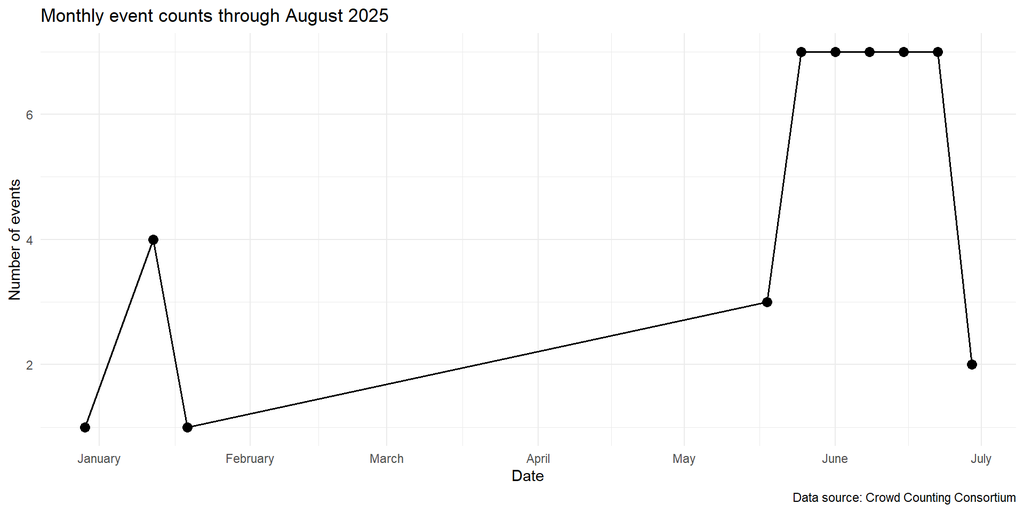

| week | n |
| --- | --- |
| 2024-12-29 | 1 |
| 2025-01-12 | 4 |
| 2025-01-19 | 1 |
| 2025-05-18 | 3 |
| 2025-05-25 | 7 |
| 2025-06-01 | 7 |
| 2025-06-08 | 7 |
| 2025-06-15 | 7 |
| 2025-06-22 | 7 |
| 2025-06-29 | 2 |

### Filling empty data

This *could* be solved with a kind of join on a data set I create with the full sequence of dates:

```r
all_weeks <- tibble(week = seq.Date(
  from = min(weekly_events$week),
  to = max(weekly_events$week),
  by = 'week'
))

all_weeks|>
  left_join(weekly_events, by='week')|>
  replace_na(list(n=0))
```

| week | n |
| --- | --- |
| 2024-12-29 | 1 |
| 2025-01-05 | 0 |
| 2025-01-12 | 4 |
| 2025-01-19 | 1 |
| 2025-01-26 | 0 |
| 2025-02-02 | 0 |
| 2025-02-09 | 0 |
| 2025-02-16 | 0 |
| 2025-02-23 | 0 |
| 2025-03-02 | 0 |
| 2025-03-09 | 0 |
| 2025-03-16 | 0 |
| 2025-03-23 | 0 |
| 2025-03-30 | 0 |
| 2025-04-06 | 0 |
| 2025-04-13 | 0 |
| 2025-04-20 | 0 |
| 2025-04-27 | 0 |
| 2025-05-04 | 0 |
| 2025-05-11 | 0 |
| 2025-05-18 | 3 |
| 2025-05-25 | 7 |
| 2025-06-01 | 7 |
| 2025-06-08 | 7 |
| 2025-06-15 | 7 |
| 2025-06-22 | 7 |
| 2025-06-29 | 2 |

### Filling empty data

```r
weekly_events<-ccc|>
  filter(online==1)|>
  mutate(week = floor_date(date, unit='week'))|>
  count(week)|>
  complete( week = seq.Date(from = min(week),
                            to = max(week), by='week'),
            fill=list(n=0) )

weekly_events
```

| week | n |
| --- | --- |
| 2024-12-29 | 1 |
| 2025-01-05 | 0 |
| 2025-01-12 | 4 |
| 2025-01-19 | 1 |
| 2025-01-26 | 0 |
| 2025-02-02 | 0 |
| 2025-02-09 | 0 |
| 2025-02-16 | 0 |
| 2025-02-23 | 0 |
| 2025-03-02 | 0 |
| 2025-03-09 | 0 |
| 2025-03-16 | 0 |
| 2025-03-23 | 0 |
| 2025-03-30 | 0 |
| 2025-04-06 | 0 |
| 2025-04-13 | 0 |
| 2025-04-20 | 0 |
| 2025-04-27 | 0 |
| 2025-05-04 | 0 |
| 2025-05-11 | 0 |
| 2025-05-18 | 3 |
| 2025-05-25 | 7 |
| 2025-06-01 | 7 |
| 2025-06-08 | 7 |
| 2025-06-15 | 7 |
| 2025-06-22 | 7 |
| 2025-06-29 | 2 |

### Filling empty data

Now the zeros are easily observed in the data:

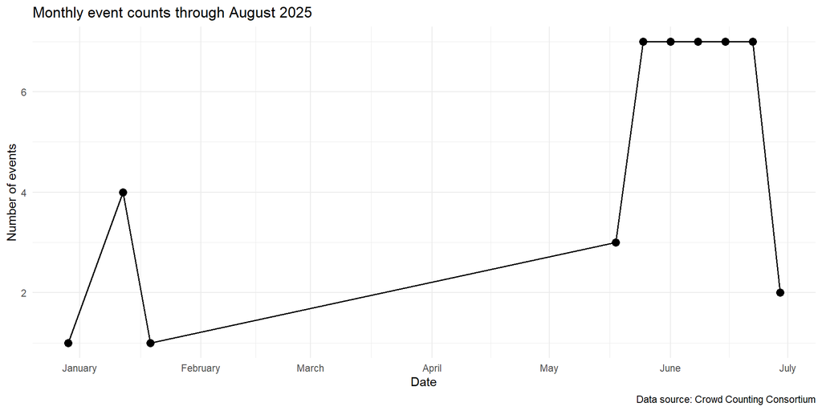

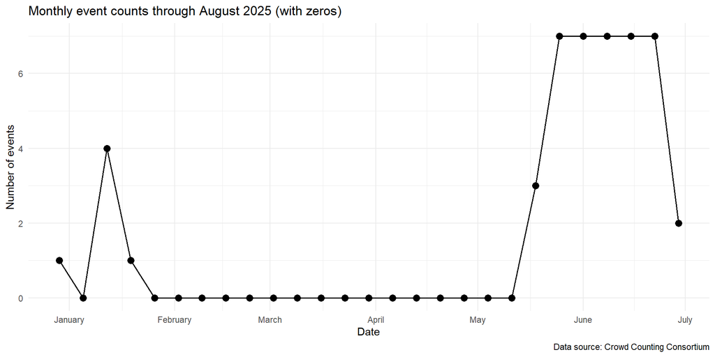

### Filling empty data

Here’s an example that would fill in 0s for all weeks for protests with and without arrests:

```r
weekly_events<-ccc|>

  mutate(week = floor_date(date, unit='week'))|>
  count(arrests_any,week)|>
  complete( week = seq.Date(from = min(week),
                            to = max(week), by='week'),
            fill=list(n=0),
            arrests_any )

weekly_events
```

| week | arrests_any | n |
| --- | --- | --- |
| 2024-12-29 | 0 | 196 |
| 2024-12-29 | 1 | 1 |
| 2025-01-05 | 0 | 351 |
| 2025-01-05 | 1 | 3 |
| 2025-01-12 | 0 | 721 |
| 2025-01-12 | 1 | 6 |
| 2025-01-19 | 0 | 556 |
| 2025-01-19 | 1 | 3 |
| 2025-01-26 | 0 | 493 |
| 2025-01-26 | 1 | 8 |
| 2025-02-02 | 0 | 663 |
| 2025-02-02 | 1 | 8 |
| 2025-02-09 | 0 | 373 |
| 2025-02-09 | 1 | 0 |
| 2025-02-16 | 0 | 654 |
| 2025-02-16 | 1 | 5 |
| 2025-02-23 | 0 | 482 |
| 2025-02-23 | 1 | 6 |
| 2025-03-02 | 0 | 983 |
| 2025-03-02 | 1 | 4 |
| 2025-03-09 | 0 | 548 |
| 2025-03-09 | 1 | 7 |
| 2025-03-16 | 0 | 833 |
| 2025-03-16 | 1 | 3 |
| 2025-03-23 | 0 | 940 |
| 2025-03-23 | 1 | 4 |
| 2025-03-30 | 0 | 1709 |
| 2025-03-30 | 1 | 2 |
| 2025-04-06 | 0 | 542 |
| 2025-04-06 | 1 | 1 |
| 2025-04-13 | 0 | 1362 |
| 2025-04-13 | 1 | 4 |
| 2025-04-20 | 0 | 395 |
| 2025-04-20 | 1 | 5 |
| 2025-04-27 | 0 | 1370 |
| 2025-04-27 | 1 | 10 |
| 2025-05-04 | 0 | 484 |
| 2025-05-04 | 1 | 11 |
| 2025-05-11 | 0 | 610 |
| 2025-05-11 | 1 | 9 |
| 2025-05-18 | 0 | 501 |
| 2025-05-18 | 1 | 7 |
| 2025-05-25 | 0 | 470 |
| 2025-05-25 | 1 | 2 |
| 2025-06-01 | 0 | 644 |
| 2025-06-01 | 1 | 9 |
| 2025-06-08 | 0 | 2792 |
| 2025-06-08 | 1 | 60 |
| 2025-06-15 | 0 | 438 |
| 2025-06-15 | 1 | 0 |
| 2025-06-22 | 0 | 615 |
| 2025-06-22 | 1 | 6 |
| 2025-06-29 | 0 | 802 |
| 2025-06-29 | 1 | 9 |
| 2025-07-06 | 0 | 434 |
| 2025-07-06 | 1 | 3 |
| 2025-07-13 | 0 | 1432 |
| 2025-07-13 | 1 | 2 |
| 2025-07-20 | 0 | 466 |
| 2025-07-20 | 1 | 7 |
| 2025-07-27 | 0 | 945 |
| 2025-07-27 | 1 | 4 |
| 2025-08-03 | 0 | 540 |
| 2025-08-03 | 1 | 7 |
| 2025-08-10 | 0 | 858 |
| 2025-08-10 | 1 | 6 |
| 2025-08-17 | 0 | 571 |
| 2025-08-17 | 1 | 8 |
| 2025-08-24 | 0 | 542 |
| 2025-08-24 | 1 | 3 |
| 2025-08-31 | 0 | 82 |
| 2025-08-31 | 1 | 0 |

### Filling empty data

```r
weekly_events<-ccc|>

  mutate(week = floor_date(date, unit='week'))|>
  count(arrests_any,week)|>
  complete( week = seq.Date(from = min(week),
                            to = max(week), by='week'),
            fill=list(n=0),
            arrests_any )

weekly_events
```

[figure not shown]

## Visualization for exploratory analysis

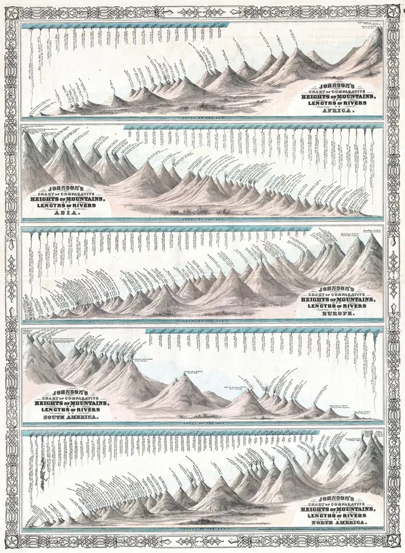

### Data

We’ve got some monthly counts of events organized by whether they were right or left wing.

```r
event_counts<-ccc|>
  mutate(month = floor_date(date, unit='month'),
         valence = factor(valence, levels=c(0, 1, 2),
                          labels=c("other/neither",
                                   'left-wing',
                                   'right-wing'))
         )|>
  count(month, valence)|>
  complete(month = seq.Date(from= min(month),
                            to=max(month),
                            by='month'),
           fill=list(n=0))|>
  drop_na()


event_counts
```

| month | valence | n |
| --- | --- | --- |
| 2025-01-01 | other/neither | 1169 |
| 2025-01-01 | left-wing | 931 |
| 2025-01-01 | right-wing | 123 |
| 2025-02-01 | other/neither | 1045 |
| 2025-02-01 | left-wing | 1071 |
| 2025-02-01 | right-wing | 49 |
| 2025-03-01 | other/neither | 1273 |
| 2025-03-01 | left-wing | 2292 |
| 2025-03-01 | right-wing | 57 |
| 2025-04-01 | other/neither | 966 |
| 2025-04-01 | left-wing | 2939 |
| 2025-04-01 | right-wing | 113 |
| 2025-05-01 | other/neither | 1215 |
| 2025-05-01 | left-wing | 2063 |
| 2025-05-01 | right-wing | 26 |
| 2025-06-01 | other/neither | 1114 |
| 2025-06-01 | left-wing | 3381 |
| 2025-06-01 | right-wing | 194 |
| 2025-07-01 | other/neither | 971 |
| 2025-07-01 | left-wing | 2298 |
| 2025-07-01 | right-wing | 22 |
| 2025-08-01 | other/neither | 1259 |
| 2025-08-01 | left-wing | 2016 |
| 2025-08-01 | right-wing | 25 |

### Parts of a plot

Required components:

1. Data and mapping: We need to choose what elements we’ll be visualizing and how they map onto different parts of the plot (what goes on the x and y axis? If we’re color coding, what variables determine colors? Or shapes?)
2. Layers: the visible representations of the data. The most important being geometries (bar, point, line etc.)
3. Scales: the mapping from data units to distances, colors, etc.
4. The remaining elements can be modified, but they’re often left at default values (ggplot assumes you want carteesian coordinates unless you say otherwise, for instance)

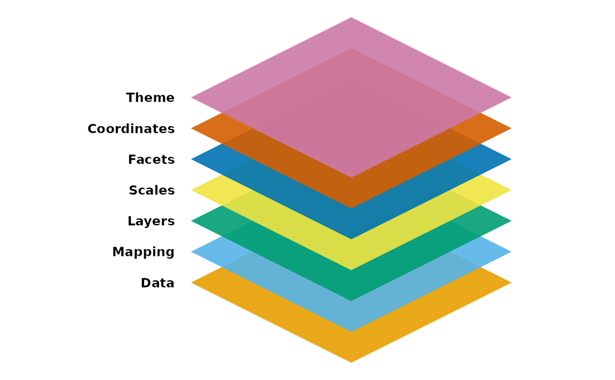

### Dimensionality

- Data is multi-dimensional, but visuals are 2D.
- A core challenge for good visualization is elegantly handling this dimensional mismatch by:
  - simplifying data
  - color/shape/symbol encoding
  - faceting

### ggplot

You’ll always start with a call to ggplot

On it’s own, this just makes empty space.

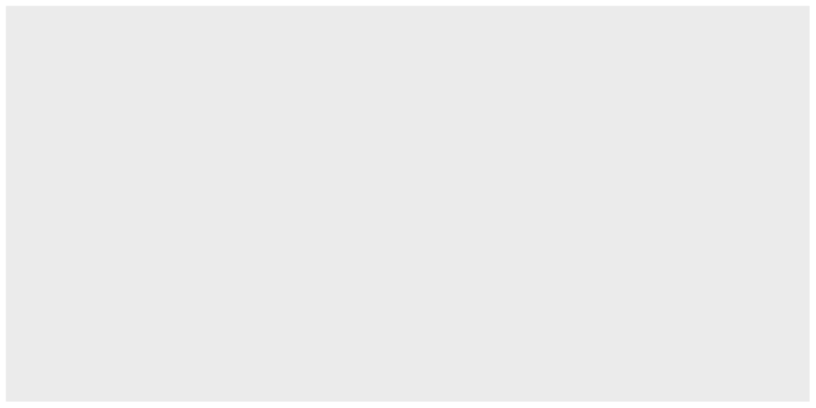

```r
ggplot()
```

Once we’ve got an aesthetic mapping, we start to get something more concrete:

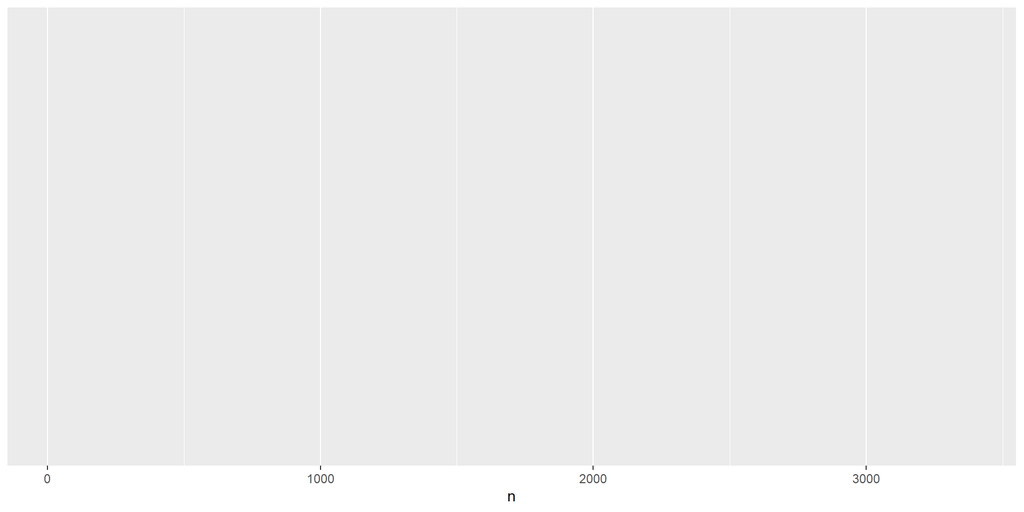

```r
base <- ggplot(data = event_counts, aes(x=n))

base
```

### ggplot geometry

We can use the `+` to add more layers to a ggplot object, and we can add more than one kind of geometry to a single visualization.

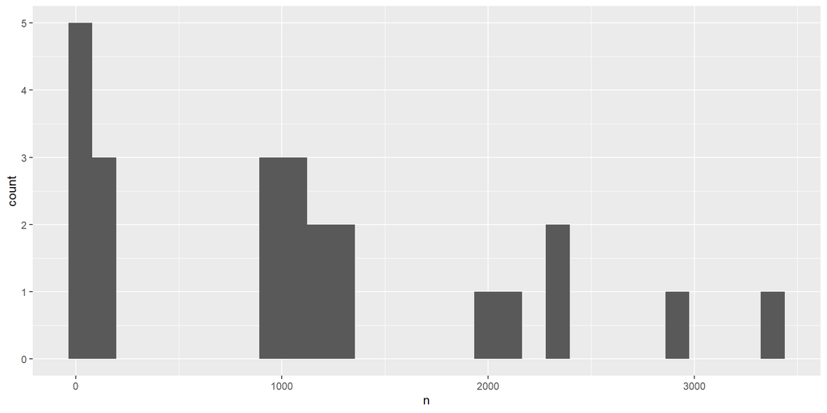

```r
base + geom_histogram()
```

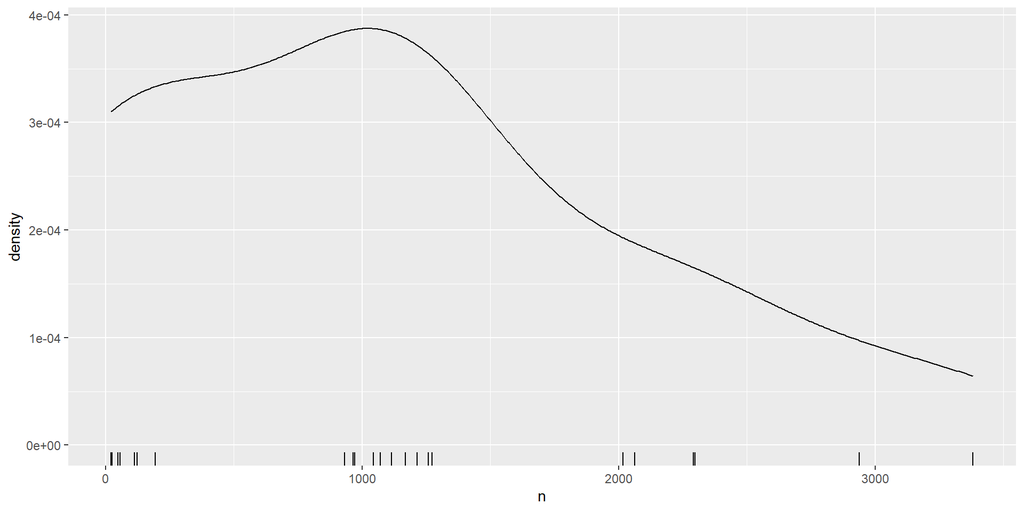

```r
base + geom_density() + geom_rug()
```

### ggplot scales

We can also change the x or y scaling from the default using `scale_` functions

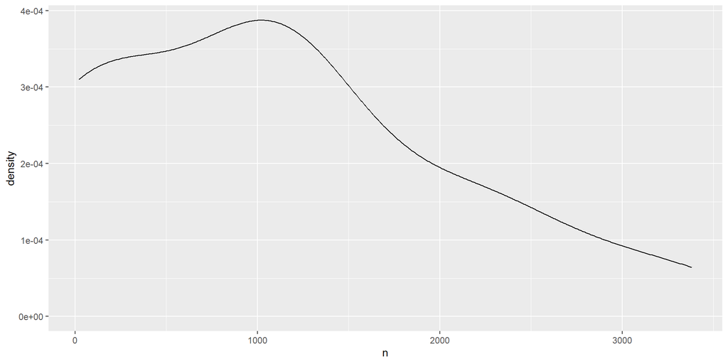

```r
base + geom_density()
```

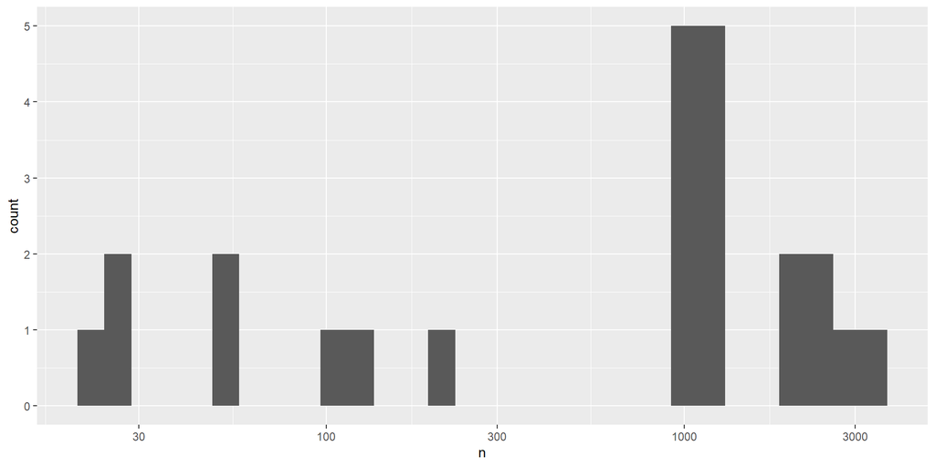

```r
base + geom_histogram() + scale_x_log10()
```

### ggplot with multiple variables

The previous examples were all univariate plots, but we have a lot more to work with.

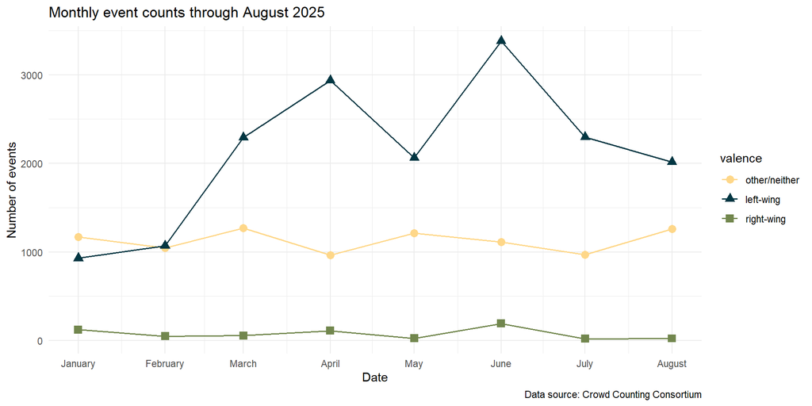

```r
library(paletteer) # package for alternate color palettes



ggplot(event_counts, aes(x = month, y = n, color = valence)) +
  geom_line(lwd=.7) +
  geom_point(aes(shape =valence), size=3) +
  theme_minimal() +
  labs(x = "Date",
       y='Number of events',
       title='Monthly event counts through August 2025',
       caption = "Data source: Crowd Counting Consortium"
      )+
scale_x_date(date_breaks = "1 month", date_labels = "%B") +
scale_color_paletteer_d("nationalparkcolors::Acadia")
```

### Facets and small multiples

Big differences in the scales can make it difficult to identify relative changes within each group. One way to deal with this is by using a facet to draw multiple version of the same plot.

```r
event_counts|>
  mutate(valence = fct_relevel(valence, "left-wing",
                                         "other/neither",
                                         "right-wing"))|>
  ggplot(aes(x = month, y = n, color = valence)) +
  geom_line(lwd=.7) +
  geom_point(aes(shape =valence), size=3) +
  theme_minimal() +
  labs(x = "Date",
       y='Number of events',
       title='Monthly event counts through August 2025',
       caption = "Data source: Crowd Counting Consortium"
      ) +
  scale_x_date(date_breaks = "1 month", date_labels = "%B") +
  scale_color_paletteer_d("nationalparkcolors::Acadia")  +
  facet_wrap(~valence, ncol=1, scales='free_y') +
  # legend no longer needed here since the facets are already labeled
  theme(legend.position = "none")
```

[output not shown]

### General tips on data visualization

- The best way to learn is through replication: find an example and adapt it. [here’s a great place to start](https://r-graph-gallery.com/)
- Care.
- Consider resolution and audience: slide decks should have big plots with minimal detail, written reports can tolerate more subtlety.
- Almost all “3d” plots are pointless.